# Data Visualization in R: Introduction to {ggplot2} Workshop

Britta Schumacher

Last updated: 22 March, 2022

*FIRST*: Many thanks to Alison Horst for the [aRt](https://github.com/allisonhorst/stats-illustrations) included in this document.

# Data Visualization with `ggplot2`

### What is `ggplot2`?

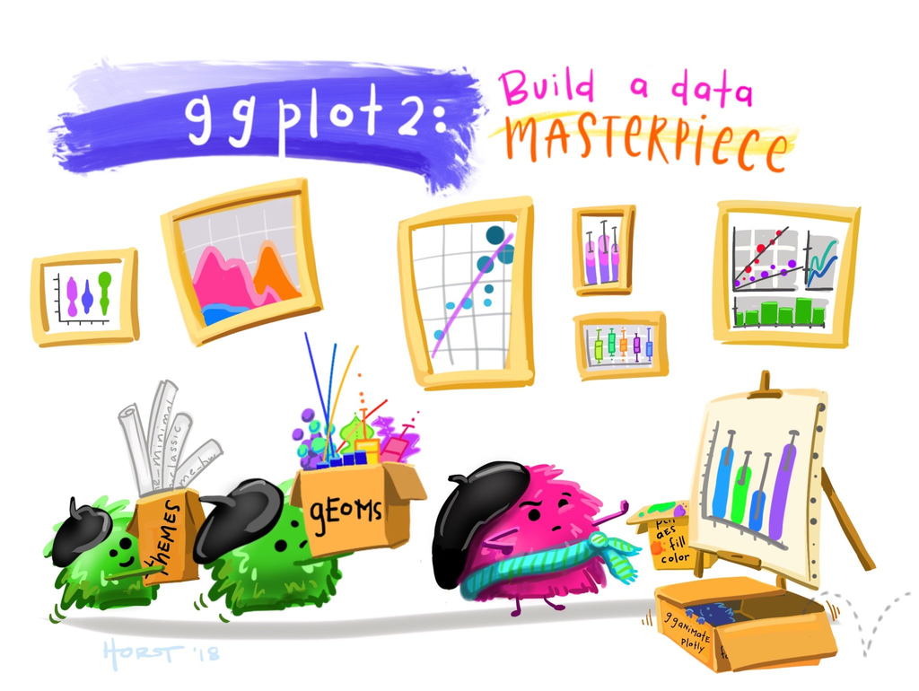

Artwork by Alison Horst

`ggplot2` is the bread and butter of data visualization; it takes clean, organized, manipulated data, and (with your direction) builds beautiful, & more importantly, *communicative*, plots. `ggplot2` is based on the *grammar of graphics*, which asserts that we can build every graph from the same few components: 1) a clean and tidy **data set**; 2) a set of **geoms** that map out data points; and 3) a **coordinate system** (in the broadest sense; i.e., how will the data be mapped onto a graphical surface). To actually display data values, we map out our variables to aesthetic things like **size**, **color**, and **x** and **y** locations; we also tell `ggplot2` the type of visualization we are interested in building (e.g., bar graph, box plot, line graph, density plots, etc.). `ggplot2` opens up [data science](https://r4ds.had.co.nz/introduction.html) to broader audiences and helps all of us communicate our science better. Download [this](https://www.rstudio.com/wp-content/uploads/2015/03/ggplot2-cheatsheet.pdf) cheat sheet and save it somewhere accessible–it’s an important tool to refer back to.

`ggplot2` works with `data.frames`, the data type we built in our previous `tidyverse` workshop. The data we feed into `ggplot2` consists of rows and columns that “live peacefully” together in a tidy `data.frame`. This means, often, we need to do some data cleaning up front to get our data into the **tidy** format we need for visualization.

# Let’s get started on some REAL*ish* data!

### Load the tidyverse and any additional required packages:

```r
#install.packages("DALEX")
library(tidyverse)
library(DALEX)
library(RColorBrewer)

data(dragons)
dragons <- view(dragons)
```

In honor of [Black Dragon Canyon Wash](https://www.alltrails.com/trail/us/utah/black-dragon-wash-trail--3) Let’s pretend we’re trying to understand how different species of chromatic dragons (a decently tempermental critter) with various life lengths compare in terms of number of scars and BMI.

### Explore

We should first familiarize ourselves with the data.

```r
dim(dragons) # view dimensions of the df
glimpse(dragons) # view the data structure and first few observations
str(dragons) # view data structure of df
colnames(dragons) # view the columns of df
```

### Wrangle

Let’s quickly brush up on wrangling and clean up this data set for our purposes. We will:

1. filter for black & blue dragons
2. select relevant columns of data
3. rename columns
4. create new columns
5. combine genus and species into a single column
6. create categorical variable to group dragons by age!

Let’s create an efficient workflow by combining **ALL** of these data wrangling steps into one; ie. let’s review harnessing the great POWERS of `tidyverse()`!

#### Now let’s pull all of these steps together!

```r
# recall how we clean and manipulate data
dragons_simple <- dragons %>%
  filter(colour %in% c("black","blue")) %>% # filter for blue & back dragons
  select(2:5,7, life_length) %>%  # select only relevant columns (height, weight, scars, colour, number_of_lost_teeth, and life_length)
  rename(teeth = number_of_lost_teeth,
         age = life_length) %>% # rename columns with terribly long names
  mutate(genus = ifelse(colour %in% c("blue"), "Sauroniops", "Jaggermeryx"), # create new column, genus, based on color; if blue = Sauroniops, if black = Jaggermeryx
         species = case_when(
              colour == "blue" & age < 1200 ~ "reike",
              colour == "blue" & age > 1200 ~ "naida",
              colour == "black" & age < 1000 ~ "ozzyi",
              colour == "black" & (age >= 1000 & age <= 1700) ~ "whido",
              colour == "black" & age > 1700 ~ "strummeri")) %>% # create species column based on colour and age
  mutate(BMI = (weight*2000)/0.45359237 / height^2) %>% # create new column, BMI (formula = (weight*2000)/0.45359237 / height^2)
  unite(genus_species, genus, species, sep = " ") %>% # combine genus and species
  mutate(age_group = as.factor(case_when(
              age < 1000 ~ "dragonling",
              age >= 1000 & age <= 2000 ~ "jouvenile",
              age > 2000 ~ "adult"))) # create categorical variables to group dragons by age

# recall how we save data
saveRDS(dragons_simple, "./out-data/dragons-tidy.RDS")
```

With this simplified and cleaned data set, we’re ready to explore! Let’s first isolate data we want to visualize by:

1. grouping observations by age_group & genus_species
2. finding the average scars, BMI, and number of teeth for each species-age combination
3. pivot_longer() into tidy format for visualizing

```r
fav_spp <- dragons_simple %>%
  group_by(age_group,genus_species) %>% # group by age group and species
  summarise(ave_scars = ave(scars),
            ave_BMI = ave(BMI),
            ave_teeth = ave(teeth)) %>% # summarise average scars, BMI, and teeth lost
  distinct() %>% # keep only distinct observations
  pivot_longer(cols = c(`ave_scars`, `ave_BMI`, `ave_teeth`), names_to = "summary_var", values_to = "ave") # pivot_longer() to format for column graph
```

### Column graph

Now that we have our data summarised and in tidy format, we’re ready to make a plot! We want to:

1. create a column graph showing the summarised by species and by age_group
2. create a different panel for each dragon species
3. make it pretty

**Note:** Only the first 3 lines of the following code are necessary to make the plot. Everything else simply modifies the appearance and make it a bit more presentable. There are *tons* of ways to customize plots – we explore only a few options below.

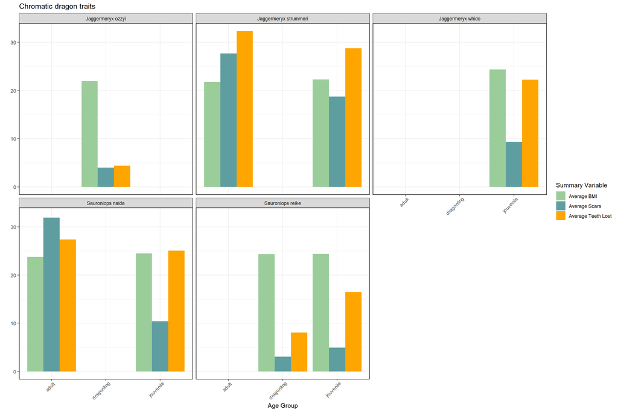

```r
ggplot(fav_spp, aes(x = age_group, y = ave, fill = summary_var)) + # fill = summary variables
  geom_col(position = "dodge") + # separate columns for each age group
  facet_wrap(~genus_species) + # create separate panels for each species
  ggtitle("Chromatic dragon traits") + # add a title
  labs(x = "Age Group", y = "", fill = "Summary Variable") + # add labels on the axes and legend
  scale_fill_manual(labels = c("Average BMI", "Average Scars", "Average Teeth Lost"), values = c("darkseagreen3", "cadetblue", "orange")) + # change colors and names
  theme_bw() + # change the theme
  theme(panel.border = element_rect(colour = "black", fill = NA, size = 0.7), # change the border color and size
        axis.text.x = element_text(angle = 45, hjust = 0.9)) # change the angle of the x axis text, change the horizontal adjustment
```

```r
ggsave("./out-plots/dragon_plot.png") # save the plot
```

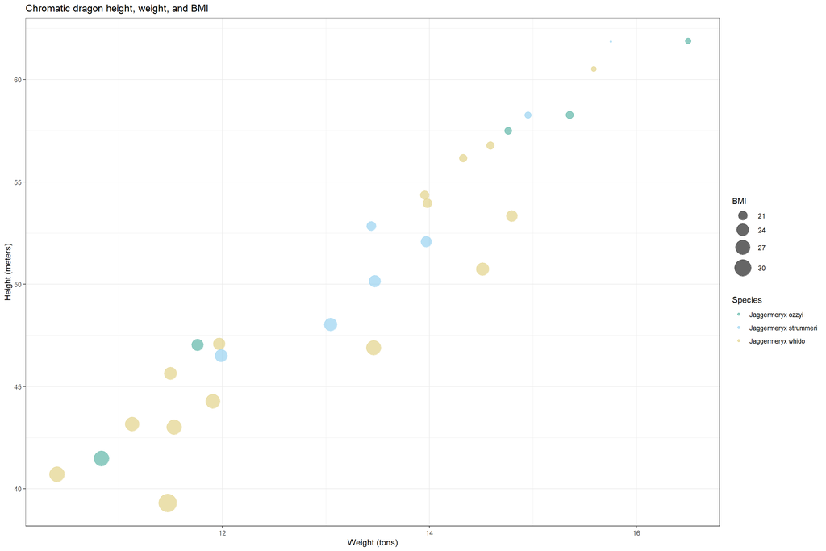

```r
dragons_simple %>% filter(genus_species != "Sauroniops reike" & genus_species != "Sauroniops naida") %>%
ggplot(.) + # fill = summary variables
  geom_point(aes(x = weight, y = height, color = genus_species, size = BMI), alpha = 0.6) + # separate columns for each age group
  scale_size_continuous(range = c(1, 11)) +
  ggtitle("Chromatic dragon height, weight, and BMI") + # add a title
  labs(x = "Weight (tons)", y = "Height (meters)", color = "Species") + # add labels on the axes and legend
  scale_color_manual(values = c("#44AA99", "#88CCEE", "#DDCC77", "#CC6677", "#117733")) + # change colors and names
  theme_bw() # change the theme
```

```r
ggsave("./out-plots/dragon_BMI.png") # save the plot
```

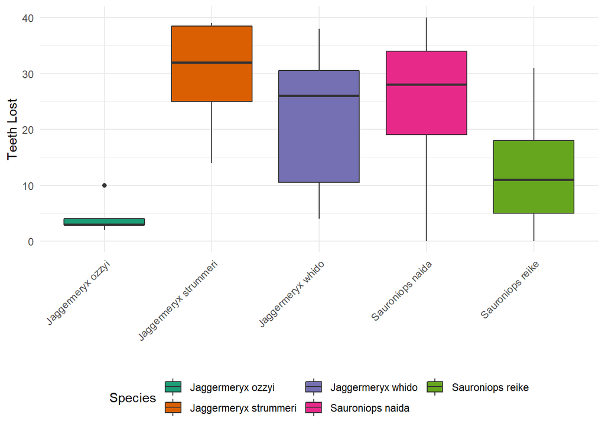

```r
ggplot(dragons_simple, aes(x = genus_species, y = teeth, fill = genus_species)) +
  geom_boxplot() + # make a boxplot
  labs(x = "", y = "Teeth Lost", fill = "Species") + # give the graph labels
  theme_minimal() + # change the theme
  scale_fill_brewer(palette = "Dark2") + # use a preset palette
  theme(axis.text.x= element_text(angle = 45, hjust = 1)) + # adjust the angle of the x axis text
  theme(legend.position = "bottom") + # move legend to the bottom
  guides(fill = guide_legend(nrow=2)) # give legend two rows
```

```r
ggsave("./out-plots/dragon_BMI.png") # save the plot
```

### Plots, plots, plots, plots, plots, plots, plots!

These are just a few of the **HUNDREDS** of different ways to visualize the same data:

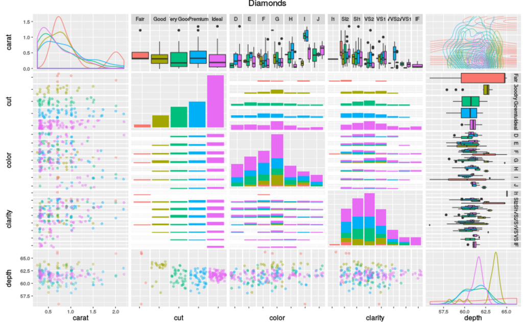

Thank you stackoverflow, for this wild visualization of all the ways we could visualize data about diamonds!

… In the end we just have to choose the method that makes the most sense for our audience, our research questions, and our data!

Additionally, aRtists everywhere are using R to make ridiculously cool pieces of [generative](https://en.wikipedia.org/wiki/Generative_art) and patterned art. Check out some talented RLadies [here](https://ijeamaka-anyene.netlify.app/) and [here](https://djnavarro.net/projects/)! Plus, [#TidyTuesday](https://github.com/rfordatascience/tidytuesday) submissions can be [absolutely](https://tanyadoesscience.com/project/tidytuesday/), [wildly](https://martindevaux.com/2021/01/tidytuesday-art-collections/), [brilliantly](https://codingwithavery.com/posts/2020-08-12-tidy-tuesday-avatar/), good.

# Bonus

What’s *especially* neat about `ggplot2` is that it interfaces seamlessly with `sf`, a package for spatial data wrangling, analysis, and visualization.`sf` treats its spatial objects as `data.frames` meaning…. we can use all of the power of the `tidyverse` to play with the data. Plus, these data look just like any other data.frame, except attached to them is a column of `geometry` that houses the coordinate information for the observation!

Below, we’ll take the the EPA air quality data Ellie & Dakoeta gathered and make it spatial for visualization!

```r
# install.packages("sf") # if you haven't done so already!
library(sf)
# read in the data
epa <- readRDS("./in-data/alldata_1980_2020.RDS")

# let's explore a bit
dim(epa) # view dimensions of the df
```

```
## [1] 251214     16
```

```r
glimpse(epa) # view the data structure and first few observations
```

```
## Rows: 251,214
## Columns: 16
## $ county             <chr> "San Bernardino", "San Bernardino", "San Bernardino~
## $ county_code        <chr> "071", "071", "071", "071", "071", "071", "071", "0~
## $ date_local         <chr> "1988-08-24", "1988-08-20", "1988-08-17", "1988-08-~
## $ parameter_code     <chr> "88502", "88502", "88502", "88502", "88502", "88502~
## $ arithmetic_mean    <dbl> 4.03279, 16.52027, 13.55705, 8.23171, 15.81250, 4.8~
## $ aqi                <int> 17, 60, 54, 34, 59, 20, 46, 67, 39, 65, 48, 56, 43,~
## $ state_code         <chr> "06", "06", "06", "06", "06", "06", "06", "06", "06~
## $ site_number        <chr> "9010", "9010", "9010", "9010", "9010", "9010", "90~
## $ latitude           <dbl> 34.19393, 34.19393, 34.19393, 34.19393, 34.19393, 3~
## $ longitude          <dbl> -116.9141, -116.9141, -116.9141, -116.9141, -116.91~
## $ sample_duration    <chr> "24 HOUR", "24 HOUR", "24 HOUR", "24 HOUR", "24 HOU~
## $ datum              <chr> "WGS84", "WGS84", "WGS84", "WGS84", "WGS84", "WGS84~
## $ pollutant_standard <chr> NA, NA, NA, NA, NA, NA, NA, NA, NA, NA, NA, NA, NA,~
## $ validity_indicator <chr> "Y", "Y", "Y", "Y", "Y", "Y", "Y", "Y", "Y", "Y", "~
## $ method             <chr> "IMPROVE Module A with Cyclone Inlet-Teflon Filter,~
## $ event_type         <chr> "None", "None", "None", "None", "None", "None", "No~
```

```r
str(epa) # view data structure of df
```

```
## tibble [251,214 x 16] (S3: tbl_df/tbl/data.frame)
##  $ county            : chr [1:251214] "San Bernardino" "San Bernardino" "San Bernardino" "San Bernardino" ...
##  $ county_code       : chr [1:251214] "071" "071" "071" "071" ...
##  $ date_local        : chr [1:251214] "1988-08-24" "1988-08-20" "1988-08-17" "1988-08-13" ...
##  $ parameter_code    : chr [1:251214] "88502" "88502" "88502" "88502" ...
##  $ arithmetic_mean   : num [1:251214] 4.03 16.52 13.56 8.23 15.81 ...
##  $ aqi               : int [1:251214] 17 60 54 34 59 20 46 67 39 65 ...
##  $ state_code        : chr [1:251214] "06" "06" "06" "06" ...
##  $ site_number       : chr [1:251214] "9010" "9010" "9010" "9010" ...
##  $ latitude          : num [1:251214] 34.2 34.2 34.2 34.2 34.2 ...
##  $ longitude         : num [1:251214] -117 -117 -117 -117 -117 ...
##  $ sample_duration   : chr [1:251214] "24 HOUR" "24 HOUR" "24 HOUR" "24 HOUR" ...
##  $ datum             : chr [1:251214] "WGS84" "WGS84" "WGS84" "WGS84" ...
##  $ pollutant_standard: chr [1:251214] NA NA NA NA ...
##  $ validity_indicator: chr [1:251214] "Y" "Y" "Y" "Y" ...
##  $ method            : chr [1:251214] "IMPROVE Module A with Cyclone Inlet-Teflon Filter, 2.2 sq. cm. - GRAVIMETRIC" "IMPROVE Module A with Cyclone Inlet-Teflon Filter, 2.2 sq. cm. - GRAVIMETRIC" "IMPROVE Module A with Cyclone Inlet-Teflon Filter, 2.2 sq. cm. - GRAVIMETRIC" "IMPROVE Module A with…
##  $ event_type        : chr [1:251214] "None" "None" "None" "None" ...
```

```r
colnames(epa) # view the columns of df
```

```
##  [1] "county"             "county_code"        "date_local"
##  [4] "parameter_code"     "arithmetic_mean"    "aqi"
##  [7] "state_code"         "site_number"        "latitude"
## [10] "longitude"          "sample_duration"    "datum"
## [13] "pollutant_standard" "validity_indicator" "method"
## [16] "event_type"
```

```r
# give this data.frame real dates!
dates <- data.frame(str_split_fixed(epa$date_local, "-", n = 3)) %>%
  rename(year = X1,
         month = X2,
         day = X3)

# bind year, month, day columns to epa data.frame
epa <- bind_cols(dates, epa)

# build_spatial
epa_sf <- st_as_sf(x = epa,
                        coords = c("longitude", "latitude"),
                        crs = "+proj=aea +lat_0=0 +lon_0=-120 +lat_1=34 +lat_2=40.5 +x_0=0 +y_0=-4000000 +datum=NAD83 +units=m +no_defs")

glimpse(epa_sf) # notice the new column, geometry
```

```
## Rows: 251,214
## Columns: 18
## $ year               <chr> "1988", "1988", "1988", "1988", "1988", "1988", "19~
## $ month              <chr> "08", "08", "08", "08", "08", "08", "08", "07", "07~
## $ day                <chr> "24", "20", "17", "13", "10", "06", "03", "30", "27~
## $ county             <chr> "San Bernardino", "San Bernardino", "San Bernardino~
## $ county_code        <chr> "071", "071", "071", "071", "071", "071", "071", "0~
## $ date_local         <chr> "1988-08-24", "1988-08-20", "1988-08-17", "1988-08-~
## $ parameter_code     <chr> "88502", "88502", "88502", "88502", "88502", "88502~
## $ arithmetic_mean    <dbl> 4.03279, 16.52027, 13.55705, 8.23171, 15.81250, 4.8~
## $ aqi                <int> 17, 60, 54, 34, 59, 20, 46, 67, 39, 65, 48, 56, 43,~
## $ state_code         <chr> "06", "06", "06", "06", "06", "06", "06", "06", "06~
## $ site_number        <chr> "9010", "9010", "9010", "9010", "9010", "9010", "90~
## $ sample_duration    <chr> "24 HOUR", "24 HOUR", "24 HOUR", "24 HOUR", "24 HOU~
## $ datum              <chr> "WGS84", "WGS84", "WGS84", "WGS84", "WGS84", "WGS84~
## $ pollutant_standard <chr> NA, NA, NA, NA, NA, NA, NA, NA, NA, NA, NA, NA, NA,~
## $ validity_indicator <chr> "Y", "Y", "Y", "Y", "Y", "Y", "Y", "Y", "Y", "Y", "~
## $ method             <chr> "IMPROVE Module A with Cyclone Inlet-Teflon Filter,~
## $ event_type         <chr> "None", "None", "None", "None", "None", "None", "No~
## $ geometry           <POINT [m]> POINT (-116.9141 34.19393), POINT (-116.9141 ~
```

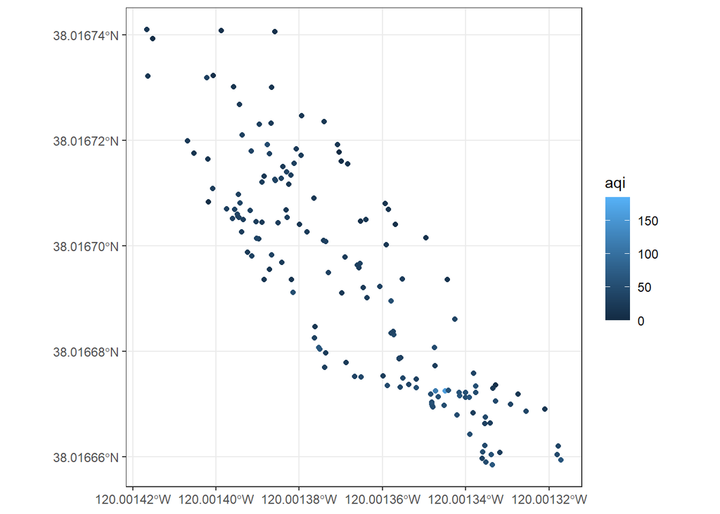

```r
# visualize
epa_sf %>% filter(year == 2019, event_type == "None") %>%
ggplot(.) +
  geom_sf(aes(color = aqi)) +
  theme_bw()
```

There are many, many ways to make maps beautiful in `ggplot` using `sf`. Anyone who says R isn’t built for spatial visualization just hasn’t tried hard enough–check out [this](https://timogrossenbacher.ch/2019/04/bivariate-maps-with-ggplot2-and-sf/) if you don’t believe me (just about the most gorgeous, creative, and well-built map I’ve ever seen).

# Resources

- Emily Burchfield’s data viz materials, [here](https://www.emilyburchfield.org/courses/data_viz/intro_to_ggplot_tutorial).
- [Secrets of a happy graphing life](https://stat545.com/secrets.html).
- [The ggplot2 cheatsheet!](https://www.rstudio.com/wp-content/uploads/2015/03/ggplot2-cheatsheet.pdf)
- Chapters 5 - 12 in [this online textbook](https://clauswilke.com/dataviz/visualizing-amounts.html) provide a great overview of when to use different visualization strategies.